# Proposal Phase of Project

datING - BDA 503 - Fall 2017

## Group name

- **datING**

## Group members

1. [Bilge Uzuner](https://mef-bda503.github.io/pj-uzunerb/)
2. [Sefa Erbas](https://mef-bda503.github.io/pj-erbass/)
3. [Türkan Sevgili](https://mef-bda503.github.io/pj-sevgilit/)

## Data

- Global Terrorism Data

#### Description:

The Global Terrorism Database ([GTD](http://start.umd.edu/gtd/about/)) includes information on terrorist events around the World (205 countries, more than 33000 cities, from 1970 through 2016 on at least 45 variables for each case, with more recent incidents including information on more than 120 variables

#### Content and Data fields:

*Geography:* Worldwide

*Time period:* 1970-2016, except 1993

*Unit of analysis:* Attack

*Variables:* >100 variables on location, tactics, perpetrators, targets, and outcomes

*Sources:* Unclassified media articles

Necessary information about mostly used fields can be found below. You can see the [GTD Codebook](http://start.umd.edu/gtd/downloads/Codebook.pdf) for broadly explained definitons on fields, important details on data collection methodology, definitions, and coding schema.

- `eventid:` Incidents from the GTD follow a 12-digit Event ID system.
- `iyear:` This field contains the year in which the incident occurred.
- `imonth:` This field contains the number of the month in which the incident occurred.
- `iday:` This field contains the numeric day of the month on which the incident occurred.
- `country:` This field identifies the country code country or location where the incident occurred.
- `region:` This field identifies the region code in which the incident occurred.
- `provstate:` This variable records the name (at the time of event) of the 1st order subnational administrative region in which the event occurs.
- `city:` This field contains the name of the city, village, or town in which the incident occurred.
- `latitude:` This field records the latitude (based on WGS1984 standards) of the city in which the event occurred.
- `longitude:` This field records the longitude (based on WGS1984 standards) of the city in which the event occurred.
- `location:` This field is used to specify additional information about the location of the incident.
- `success:` Success of a terrorist strike is defined according to the tangible effects of the attack. Success is not judged in terms of the larger goals of the perpetrators.

## Objectives

- The purpose of the analysis is to understand the Turkey’s Terorism Statistics on the basis of the cities, districts, dates, seasons etc.
- Try to define the factors that influence the terror attacks in Turkey.
- A clear understanding of the data to see if we can locate useful insights about where and when terror attacks occur in Turkey.
- To create an opinion on the relatively risky and secure regions based on past experience, by in-depth analysis of the terrorist attacks in Turkey, also to see relatively safe and risky periods during the year.

## Tentative Plan

| Activity | Deadline |
| --- | --- |
| Peer Review of Proposal Phase | Oct. 29 - 31 |
| Minimal Working Report studies | Nov 1 - Dec 1 |
| Minimal Working Report Peer Review | Dec. 8 |
| Final Report studies | Dec. 10- 15 |
| Peraparation of Presentation | Dec. 10- 15 |
| FR/Presentation Peer Review | Dec. 20- 22 |

## Abstract

*Definition of terrorism:* “The threatened or actual use of illegal force and violence by a non-state actor to attain a political, economic, religious, or social goal through fear, coercion, or intimidation.”

Terrorism is the largest human-oriented criminal organization that has become a common problem globally. Nowadays, it is known that the underlying reason of most of today’s terrorist activities is strategic actions and international purposes. Terrorist attacks in a country can take place because of interior reasons (economic prosperity, socio-cultural, educational system) or other factors. The most important of factor is the geopolitical position of the country.

## Initial Analysis

- Some initial exploratory analysis of GTD dataset and Turkey terrorism statistics can be found below.

```r
# Select columns that will use in EDA
gtd.turkey = select (turkey.gtd , eventid, year = iyear, month = imonth, day=iday, country_code = country,
                     country_name=country_txt,region_code=region, region_name=region_txt, provstate,city,
                     latitude,longitude,location,success, attacktype1=attacktype1_txt,
                     attacktype2=attacktype2_txt,attacktype3=attacktype3_txt,targtype1=targtype1_txt,
                     targsubtype1=targsubtype1_txt,weaptype1=weaptype1_txt, weapsubtype1=weapsubtype1_txt,
                     property,propextent_txt,propvalue,gname,nkill,nwound)

# Summary of gtd.turkey structure
# str(gtd.turkey)
glimpse(gtd.turkey)
```

```
## Observations: 4,106
## Variables: 27
## $ eventid        <dbl> 197004250001, 197008310001, 197010020002, 19701...
## $ year           <int> 1970, 1970, 1970, 1970, 1970, 1970, 1970, 1970,...
## $ month          <int> 4, 8, 10, 10, 10, 10, 10, 11, 11, 11, 12, 12, 1...
## $ day            <int> 25, 31, 2, 3, 3, 6, 27, 10, 21, 23, 24, 29, 7, ...
## $ country_code   <int> 209, 209, 209, 209, 209, 209, 209, 209, 209, 20...
## $ country_name   <fctr> Turkey, Turkey, Turkey, Turkey, Turkey, Turkey...
## $ region_code    <int> 10, 10, 10, 10, 10, 10, 10, 10, 10, 10, 10, 10,...
## $ region_name    <fctr> Middle East & North Africa, Middle East & Nort...
## $ provstate      <fctr> Istanbul, Ankara, Izmir, Ankara, Ankara, Ankar...
## $ city           <fctr> Istanbul, Ankara, Izmir, Ankara, Ankara, Ankar...
## $ latitude       <dbl> 41.01484, 39.91839, 38.42371, 39.91839, 39.9183...
## $ longitude      <dbl> 28.96141, 32.86560, 27.13421, 32.86560, 32.8656...
## $ location       <fctr> , , , , , , , , , , , , , , , , , , , , , , , ,
## $ success        <int> 1, 1, 1, 1, 1, 0, 1, 1, 1, 1, 0, 0, 1, 1, 0, 1,...
## $ attacktype1    <fctr> Bombing/Explosion, Bombing/Explosion, Bombing/...
## $ attacktype2    <fctr> , , , , , , , , , , , , , , , , , , , , , , , ,
## $ attacktype3    <fctr> , , , , , , , , , , , , , , , , , , , , , , , ,
## $ targtype1      <fctr> Airports & Aircraft, Military, Military, Gover...
## $ targsubtype1   <fctr> Airline Officer/Personnel, Military Unit/Patro...
## $ weaptype1      <fctr> Explosives/Bombs/Dynamite, Explosives/Bombs/Dy...
## $ weapsubtype1   <fctr> Unknown Explosive Type, Unknown Explosive Type...
## $ property       <int> 1, 1, 1, 1, 1, 1, 1, 1, 1, 1, 1, 0, 1, 1, 0, 1,...
## $ propextent_txt <fctr> , , , , , , , , , Minor (likely < $1 million),...
## $ propvalue      <dbl> NA, NA, NA, NA, NA, NA, NA, NA, NA, 25000, NA, ...
## $ gname          <fctr> Palestinians, Turkish People's Liberation Army...
## $ nkill          <int> 0, 0, 0, NA, 0, 0, 0, 0, 0, NA, 0, 0, 0, NA, 0,...
## $ nwound         <int> 0, 0, 0, NA, 0, 0, 0, 0, 0, NA, 0, 1, 0, NA, 0,...
```

The data set that will use in project and initial exploratory data analysis on it consists of 4,106 observations and 27 variables.

```r
# Summary by provstate respect to event and casualties (Pivot)
gtd.turkey.provstate= group_by(gtd.turkey, provstate) %>%
  summarise(numberOfEvents = length(eventid), numberOfCasualties = sum(nkill, na.rm = TRUE)) %>%
  ungroup()

gtd.turkey.provstate
```

```
## # A tibble: 71 x 3
##    provstate numberOfEvents numberOfCasualties
##       <fctr>          <int>              <int>
##  1                        1                  3
##  2     Adana             97                 73
##  3  Adiyaman             17                 59
##  4      Agri             46                223
##  5    Amasya              2                  1
##  6    Ankara            298                383
##  7   Antalya             31                 23
##  8   Ardahan              5                  9
##  9    Artvin              4                 10
## 10     Aydin              6                  6
## # ... with 61 more rows
```

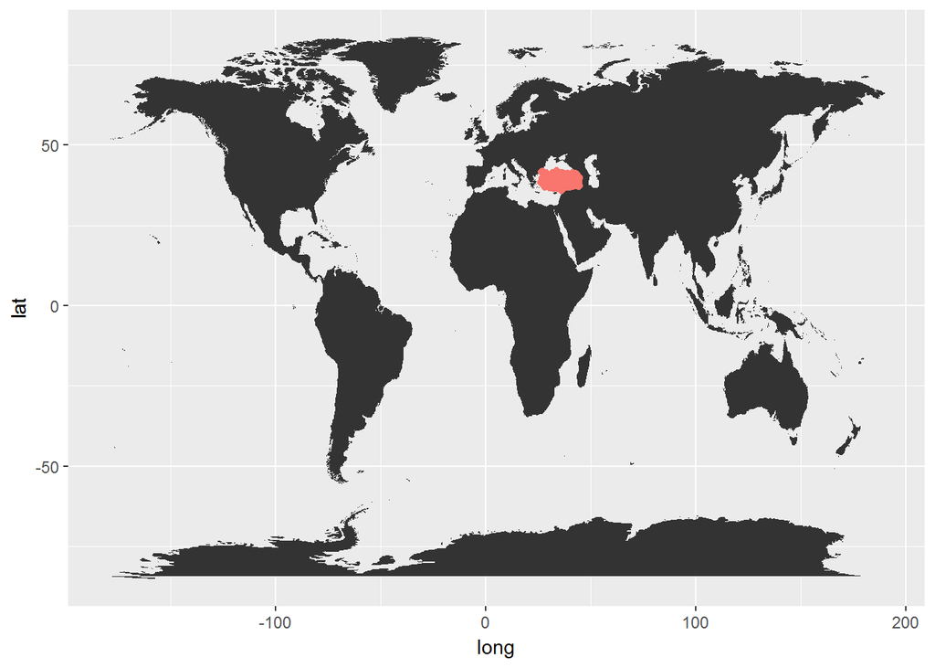

```r
library(ggmap)
turkey.map <- map_data("world")

ggplot() + geom_polygon(data = turkey.map, aes(x =  long, y = lat, group = group))+
geom_point(data = gtd.turkey, aes(x = longitude, y = latitude,color="red" ), show.legend = FALSE)
```

```r
library(ggmap)
library(mapproj)
map <- get_map(location = 'Turkey', zoom = 5)
ggmap(map)
```

[output not shown]

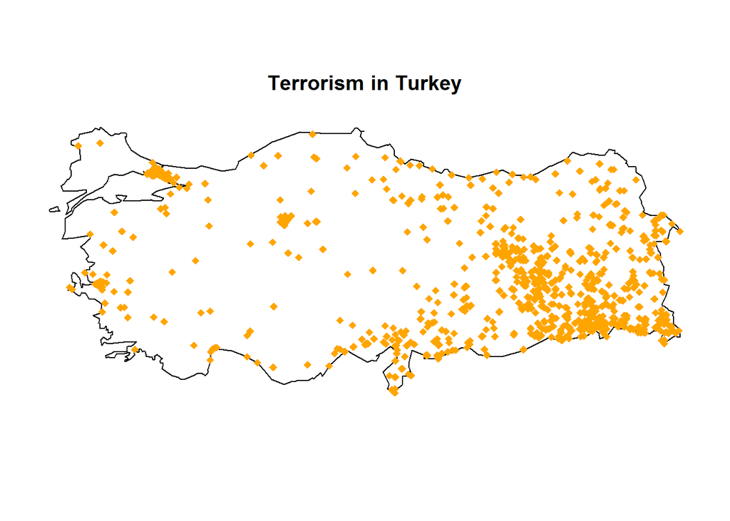

```r
library(sp)
library(maptools)
library(RColorBrewer)
library(maps)
library(mapdata)

lon_lat <- data.frame(lon=gtd.turkey$longitude, lat=gtd.turkey$latitude)
map("world2Hires", "Turkey")
points(lon_lat$lon, lon_lat$lat, col="orange", pch=18)
title("Terrorism in Turkey")
```

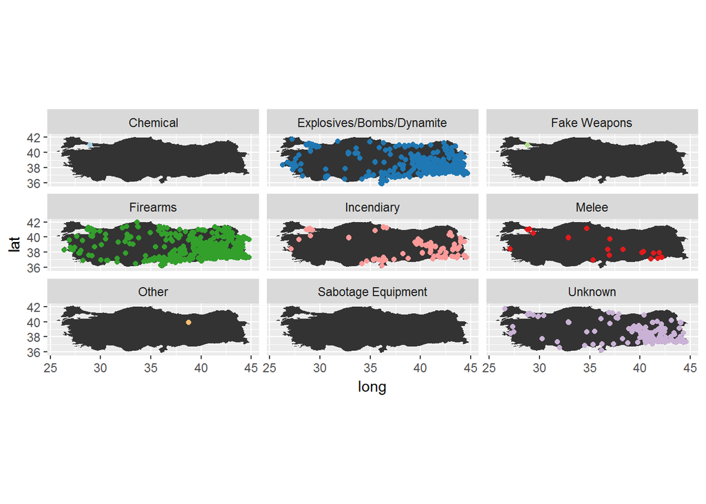

```r
#What are the most used weapons?
weapons<-unique(gtd.turkey$weaptype1)
library(ggmap)
map_tr<-map_data("world2Hires","Turkey")
map_by_weapon<- ggplot() + geom_polygon(data = map_tr, aes(x=long, y = lat, group = group)) +
  coord_fixed(0.75)
map_by_weapon<-map_by_weapon+geom_point(data=gtd.turkey,aes(x=longitude,y=latitude,color=as.factor(weaptype1)))
map_by_weapon<-map_by_weapon+scale_color_brewer(palette="Paired")+facet_wrap(~weaptype1,ncol=3)+guides(color=F)
map_by_weapon
```

## Univariate Analysis

### year_global

```r
plot1<-ggplot(data=gtd) +
  geom_area(mapping=aes(x=iyear), stat="count", fill= ('#e67e22')) +
  ggtitle("Yearly Terrorist Attacks, 1970-2016", subtitle = "Source: Global Terrorism Database, START Consortium")

plot2<-ggplot(data=gtd.turkey) +
  geom_area(mapping=aes(x=year), stat="count", fill= ('#e67e22')) +
  ggtitle("Yearly Terrorist Attacks, 1970-2016", subtitle = "Turkey")


grid.arrange(plot1,
             plot2,
             ncol=2)
```

[output not shown]

### year

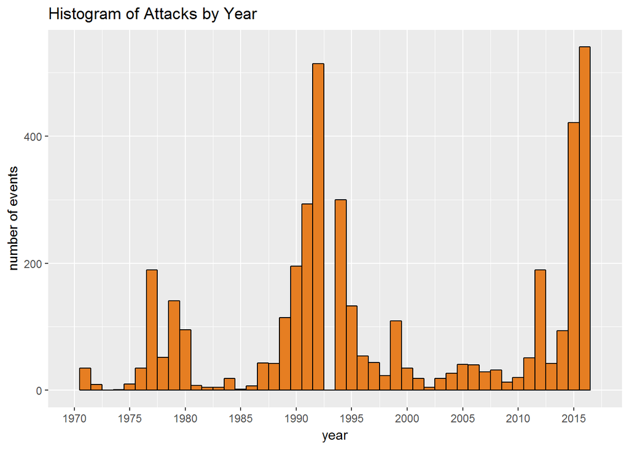

```r
ggplot(gtd.turkey, aes(gtd.turkey$year)) +
  geom_histogram(fill= ('#e67e22'), color='black', binwidth=1) +
  scale_x_continuous(limit=c(1970, 2017), breaks=seq(1970, 2017, by = 5)) +
  labs(x= 'year', y= 'number of events') +
  ggtitle('Histogram of Attacks by Year')
```

### month

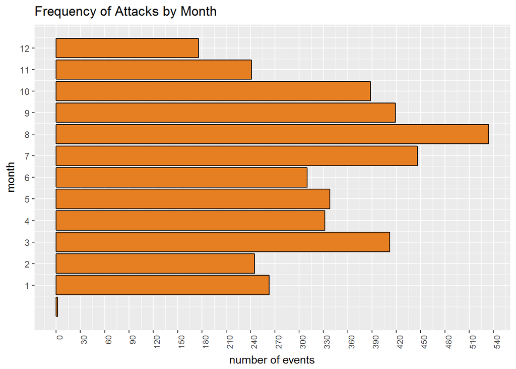

```r
ggplot(gtd.turkey, aes(gtd.turkey$month)) +
  geom_bar(fill= ('#e67e22'), color='black') +
  scale_x_continuous(breaks=seq(1, 12, by = 1)) +
  scale_y_continuous(breaks=seq(0, 1000, by = 30)) +
  theme(axis.text.x = element_text(angle=90, size=8,vjust=1, hjust=1)) +
  labs(x= 'month', y= 'number of events') +
  ggtitle('Frequency of Attacks by Month') +
  coord_flip()
```

Datada month kolonu 0 olan satirlarin da oldugunu bu tablodan görmüs olduk.

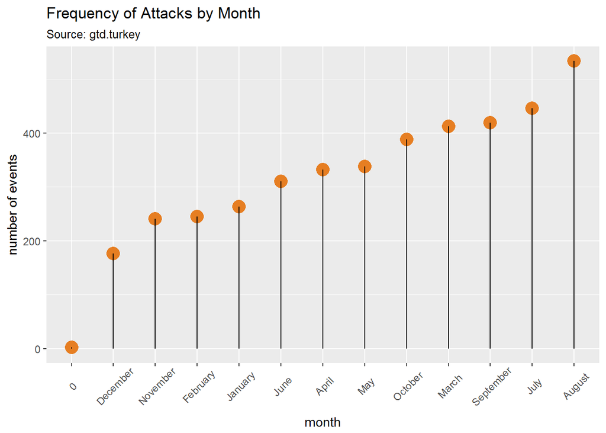

```r
#Grouped by month

gtd.turkey.month<-gtd.turkey%>%
  group_by(month)%>%
  summarise(numberOfEvents=n())

gtd.turkey.month$month[gtd.turkey.month$month == 0] <- 0
gtd.turkey.month$month[gtd.turkey.month$month == 1] <- "January"
gtd.turkey.month$month[gtd.turkey.month$month == 2] <- "February"
gtd.turkey.month$month[gtd.turkey.month$month == 3] <- "March"
gtd.turkey.month$month[gtd.turkey.month$month == 4] <- "April"
gtd.turkey.month$month[gtd.turkey.month$month == 5] <- "May"
gtd.turkey.month$month[gtd.turkey.month$month == 6] <- "June"
gtd.turkey.month$month[gtd.turkey.month$month == 7] <- "July"
gtd.turkey.month$month[gtd.turkey.month$month == 8] <- "August"
gtd.turkey.month$month[gtd.turkey.month$month == 9] <- "September"
gtd.turkey.month$month[gtd.turkey.month$month == 10] <- "October"
gtd.turkey.month$month[gtd.turkey.month$month == 11] <- "November"
gtd.turkey.month$month[gtd.turkey.month$month == 12] <- "December"


gtd.turkey.month <- gtd.turkey.month[order(gtd.turkey.month$numberOfEvents), ]
gtd.turkey.month$month <- factor(gtd.turkey.month$month, levels = gtd.turkey.month$month)


library(ggplot2)

# Plot
ggplot(gtd.turkey.month, aes(x=month, y=numberOfEvents)) +
  geom_point(size=5,color='#e67e22') +
  geom_segment(aes(x=month,
                   xend=month,
                   y=0,
                   yend=numberOfEvents)) +
  labs(x= 'month', y= 'number of events') +
  labs(title="Frequency of Attacks by Month",
       subtitle="Source: gtd.turkey") +
  theme(axis.text.x = element_text(angle=45, vjust=0.6))
```

### provstate

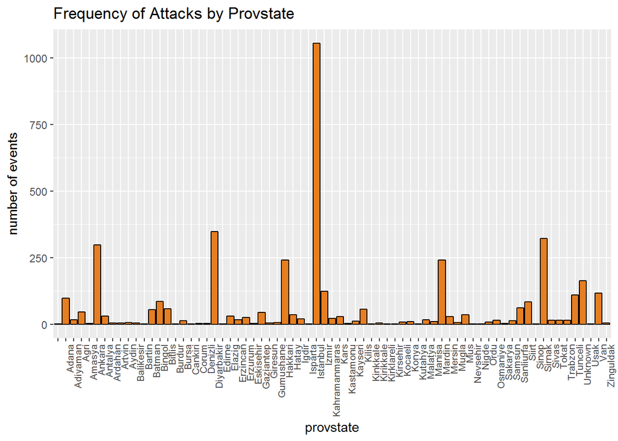

```r
ggplot(gtd.turkey, aes(gtd.turkey$provstate)) +
  geom_bar(fill= ('#e67e22'), color='black') +
  theme(axis.text.x = element_text(angle=90, size=8,vjust=1, hjust=1)) +
  labs(x= 'provstate', y= 'number of events') +
  ggtitle('Frequency of Attacks by Provstate')
```

### success-pie

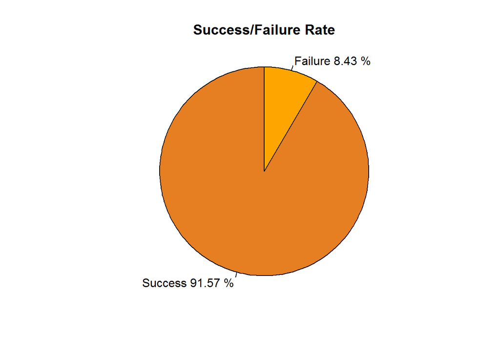

```r
#percentages
a<-gtd.turkey %>%
  count(success)

data=c(a$n)
pct = (data/sum(data))*100
pct = round(pct,2)
labels = c("Failure", "Success")
labels = paste(labels,pct, "%")
col = c("orange", '#e67e22')
pie(pct,col = col, radius = 1, init.angle = 90, clockwise = TRUE,
    labels =labels, main = "Success/Failure Rate")
```

### Attack type

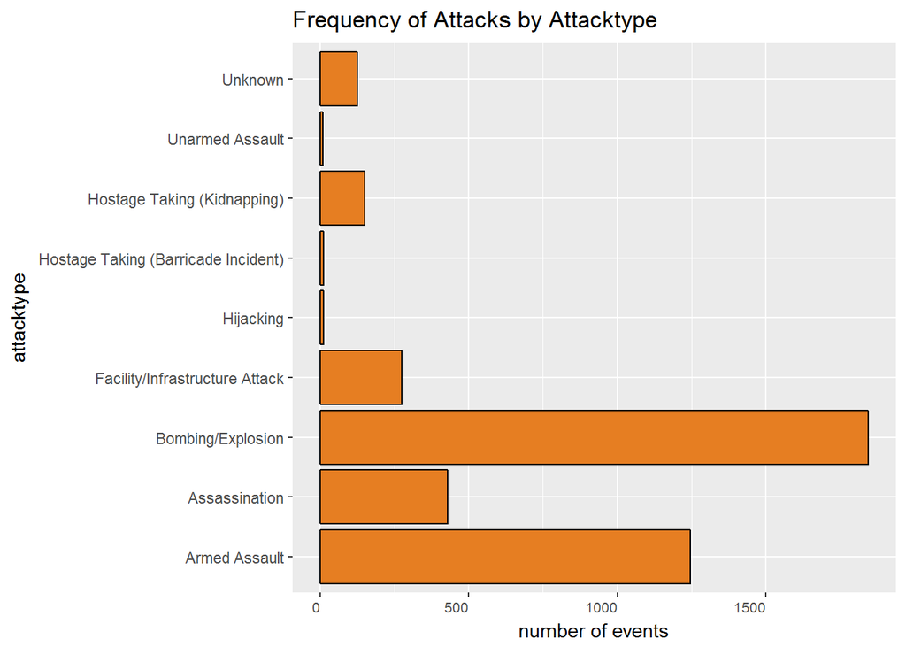

```r
ggplot(gtd.turkey, aes(gtd.turkey$attacktype1)) +
  geom_bar(fill= I('#e67e22'), color='black') +
  theme(axis.text.x = element_text(size=8,vjust=1, hjust=1)) +
  labs(x= 'attacktype', y= 'number of events') +
  ggtitle('Frequency of Attacks by Attacktype') +
  coord_flip()
```

### Target type

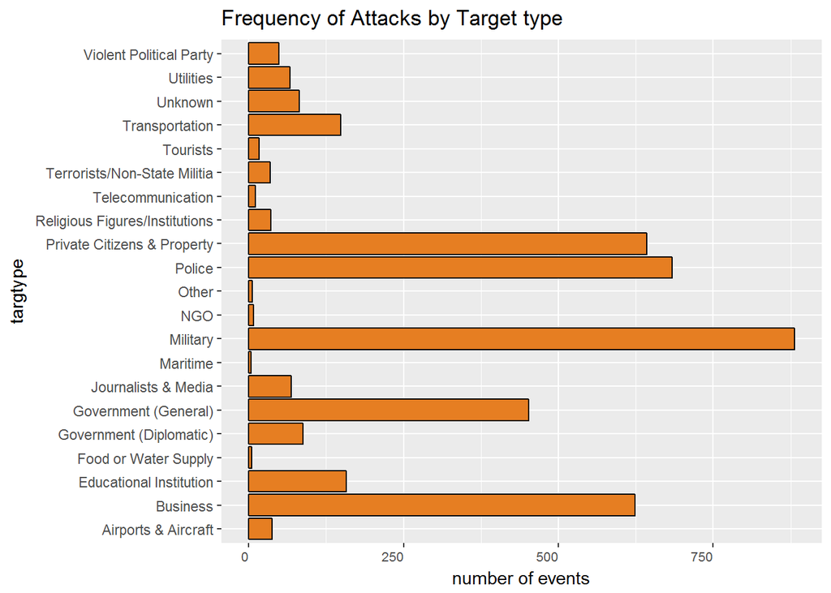

```r
ggplot(gtd.turkey, aes(gtd.turkey$targtype1)) +
  geom_bar(fill= ('#e67e22'), color='black') +
  theme(axis.text.x = element_text(size=8,vjust=1, hjust=1)) +
  labs(x= 'targtype', y= 'number of events') +
  ggtitle('Frequency of Attacks by Target type') +
  coord_flip()
```

### Weapon type

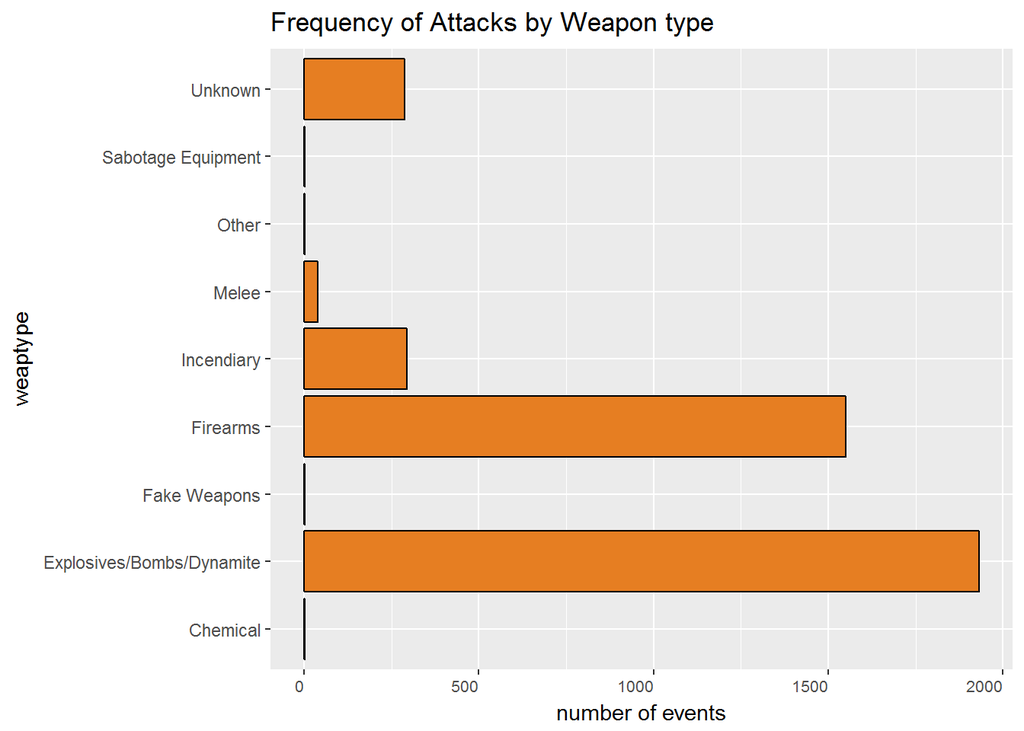

```r
ggplot(gtd.turkey, aes(gtd.turkey$weaptype1)) +
  geom_bar(fill= ('#e67e22'), color='black') +
  theme(axis.text.x = element_text(size=8,vjust=1, hjust=1)) +
  labs(x= 'weaptype', y= 'number of events') +
  ggtitle('Frequency of Attacks by Weapon type') +
  coord_flip()
```

### Group Name

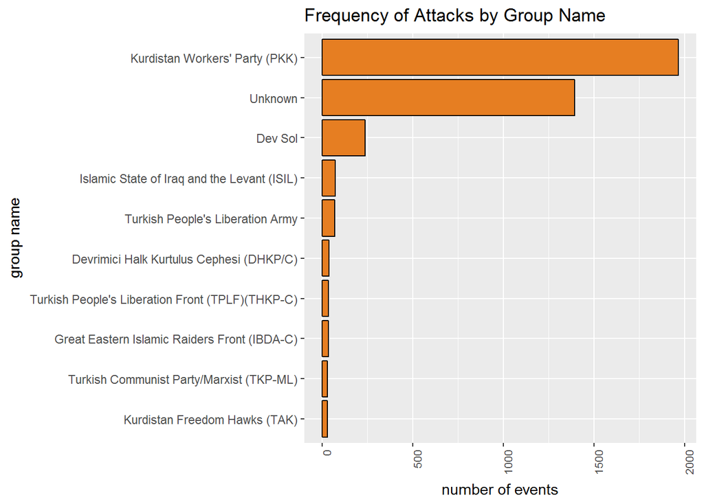

```r
gtd.turkey %>%
    group_by(gname)%>% # group by gname
    count() %>% # count the number of times a gname appear
    arrange(desc(n)) %>% # subset by rows based on condition
    head(n=10) %>%
      ggplot(aes(x=reorder(gname,n),y=n))+
      geom_bar(stat = "identity",fill= ('#e67e22'), color='black') +
      theme(axis.text.x = element_text(angle=90,size=8,vjust=1, hjust=1)) +
      labs(x= 'group name', y= 'number of events') +
      ggtitle('Frequency of Attacks by Group Name') +
      coord_flip()
```

## Bivariate Analysis

### Attacks / Casualities

```r
# Summary by year respect to event and casualties (Pivot)
gtd.turkey.year= group_by(gtd.turkey, year) %>%
  summarise(numberOfEvents = length(eventid), numberOfCasualties = sum(nkill, na.rm = TRUE))
gtd.turkey.year
```

```
## # A tibble: 45 x 3
##     year numberOfEvents numberOfCasualties
##    <int>          <int>              <int>
##  1  1970             12                  0
##  2  1971             35                  1
##  3  1972              9                  3
##  4  1974              1                  0
##  5  1975             10                  0
##  6  1976             35                  7
##  7  1977            189                 29
##  8  1978             52                 40
##  9  1979            141                123
## 10  1980             95                111
## # ... with 35 more rows
```

[figure not shown]

```r
ggplot(gtd.turkey.year, aes(x = year)) +
  geom_line(aes(y = numberOfEvents), size = 2,colour = '#e67e22') +
  geom_line(aes(y = numberOfCasualties), size = 2, ,colour = ('#2980b9'), alpha=0.5) +
  scale_x_continuous(breaks=seq(1970,2017,1)) +
  annotate("text", x = c(2010,2010), y = c(1200,1100),
           label = c("Total Casualities", "Total Attacks"), colour = c(('#e67e22'), ('#2980b9')), size = 4)  +
  ggtitle("Attacks / Casualities by Years") +
  theme(axis.text.x = element_text(angle=90, size=8)) +
  labs(x = "year", y = "attacks / casualities")
```

### Success/Failure Rate

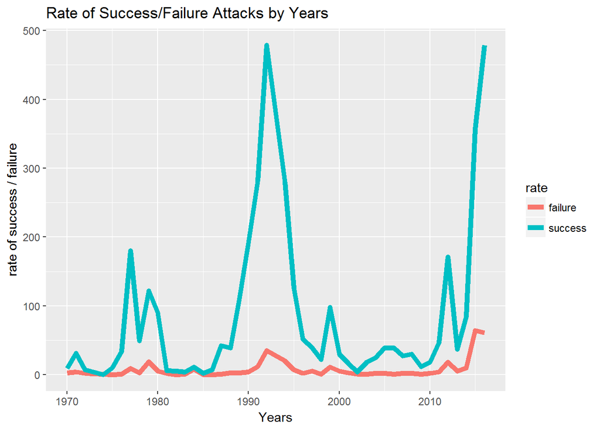

```r
gtd.turkey %>%
  mutate(total = 1) %>% # total attacks that year (creates a new variable)
  count(year, wt=total-success) %>% # failed attempt
  cbind("failure") -> failure
  colnames(failure)[3] <- "rate"


gtd.turkey %>%
  count(year, wt = success) %>%
  cbind("success")-> success
colnames(success)[3] <- "rate"

rbind(failure,success) %>%
  ggplot(aes(year,n)) +
  geom_line(aes(group=rate, colour=rate),size = 2)+
  ggtitle("Rate of Success/Failure Attacks by Years") +
  labs(x = "Years", y = "rate of success / failure")
```

### Killed/Wounded Rate

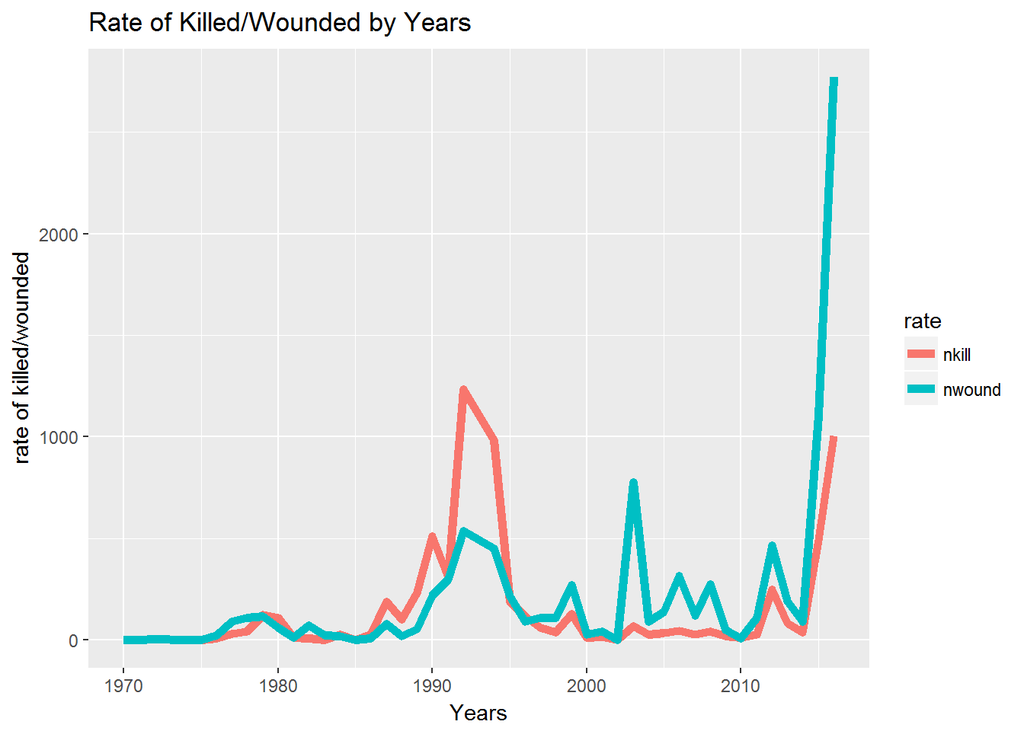

```r
gtd.turkey %>%
  mutate(total = 1) %>% # total attacks that year (creates a new variable)
  count(year, wt=nkill) %>% # failed attempt
  cbind("nkill") -> killed
  colnames(killed)[3] <- "rate"

gtd.turkey %>%
  count(year, wt = nwound) %>%
  cbind("nwound")-> wounded
colnames(wounded)[3] <- "rate"

rbind(killed,wounded) %>%
  ggplot(aes(year,n)) +
  geom_line(aes(group=rate, colour=rate),size = 2)+
  ggtitle("Rate of Killed/Wounded by Years") +
  labs(x = "Years", y = "rate of killed/wounded")
```

```r
d1<-gtd.turkey %>%
  select(nkill, nwound) %>%
  mutate(nkill = ifelse(is.na(nkill), 0, nkill)) %>%
  mutate(nwound = ifelse(is.na(nwound), 0, nwound)) %>%
  mutate(Injury_Death = nkill+nwound)
```

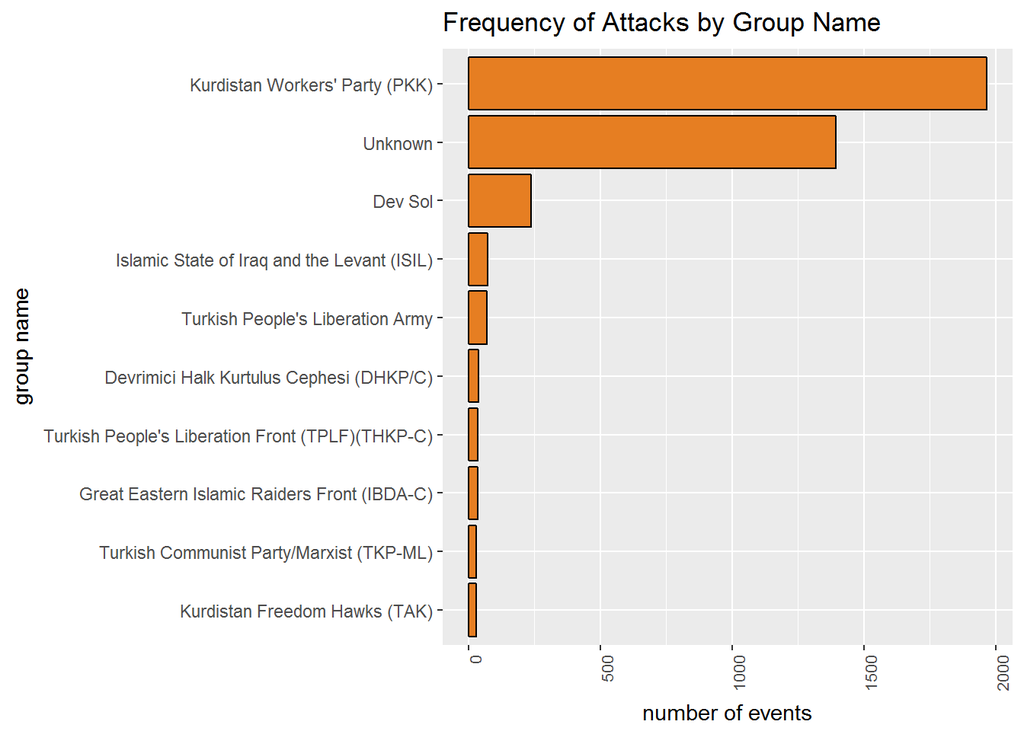

```r
gtd.turkey %>%
    group_by(gname)%>% # group by gname
    count() %>% # count the number of times a gname appear
    arrange(desc(n)) %>% # subset by rows based on condition
    head(n=10) %>%
      ggplot(aes(x=reorder(gname,n),y=n))+
      geom_bar(stat = "identity",fill= ('#e67e22'), color='black') +
      theme(axis.text.x = element_text(angle=90,size=8,vjust=1, hjust=1)) +
      labs(x= 'group name', y= 'number of events') +
      ggtitle('Frequency of Attacks by Group Name') +
      coord_flip()
```

### Terrorist attacks in Turkey between 1970-2016 by attack type

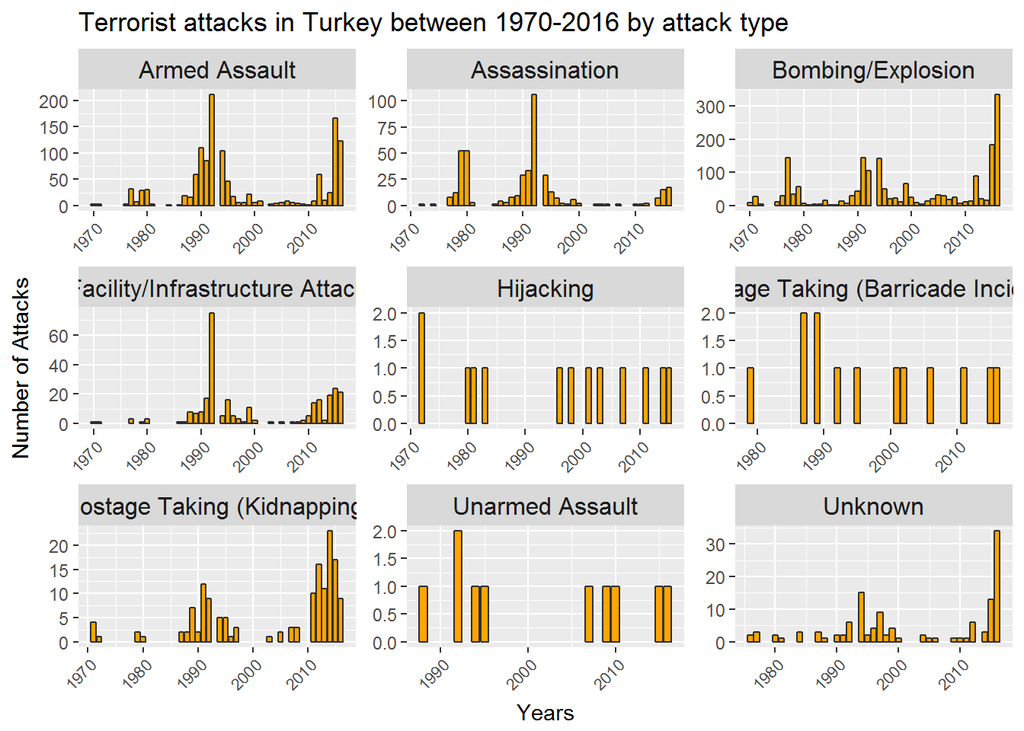

```r
ggplot(gtd.turkey, aes(x = year))+ labs(title ="Terrorist attacks in Turkey between 1970-2016 by attack type", x = "Years", y = "Number of Attacks", size = 15) +
  geom_bar(colour = "grey19", fill = "orange") + facet_wrap(~attacktype1,scales = "free", ncol = 3) +
  theme(axis.text.x = element_text(angle=45,hjust = 1, size = 8)) + theme(strip.text = element_text(size = 12))
```

### Yearly terrorist attacks by ATTACK type

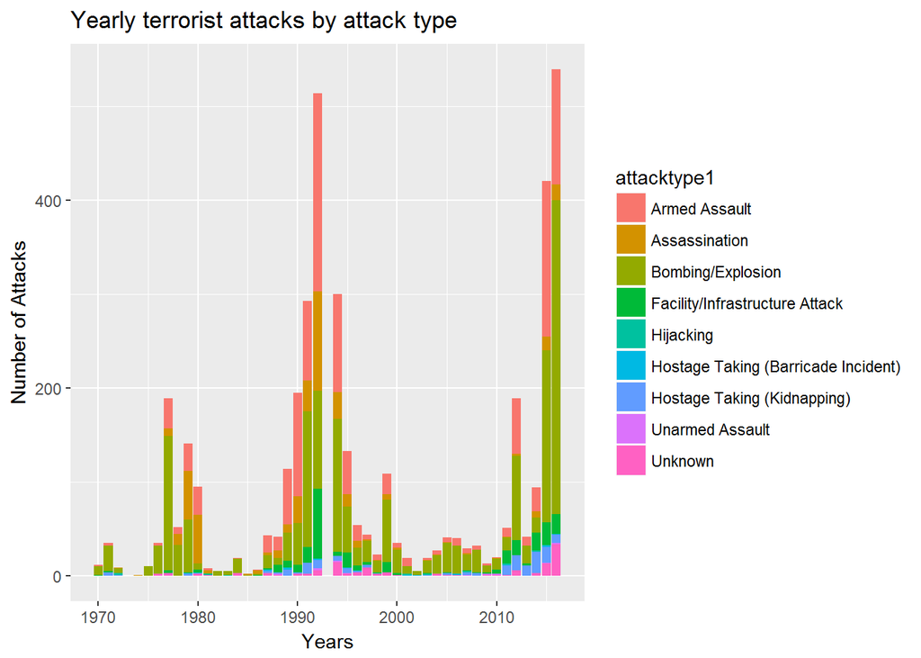

```r
  ggplot(data=gtd.turkey, aes(x=year,fill=attacktype1)) + geom_bar() + ggtitle("Yearly terrorist attacks by attack type")+
    labs(x = "Years", y = "Number of Attacks")
```

### Yearly terrorist attacks by Weapon type

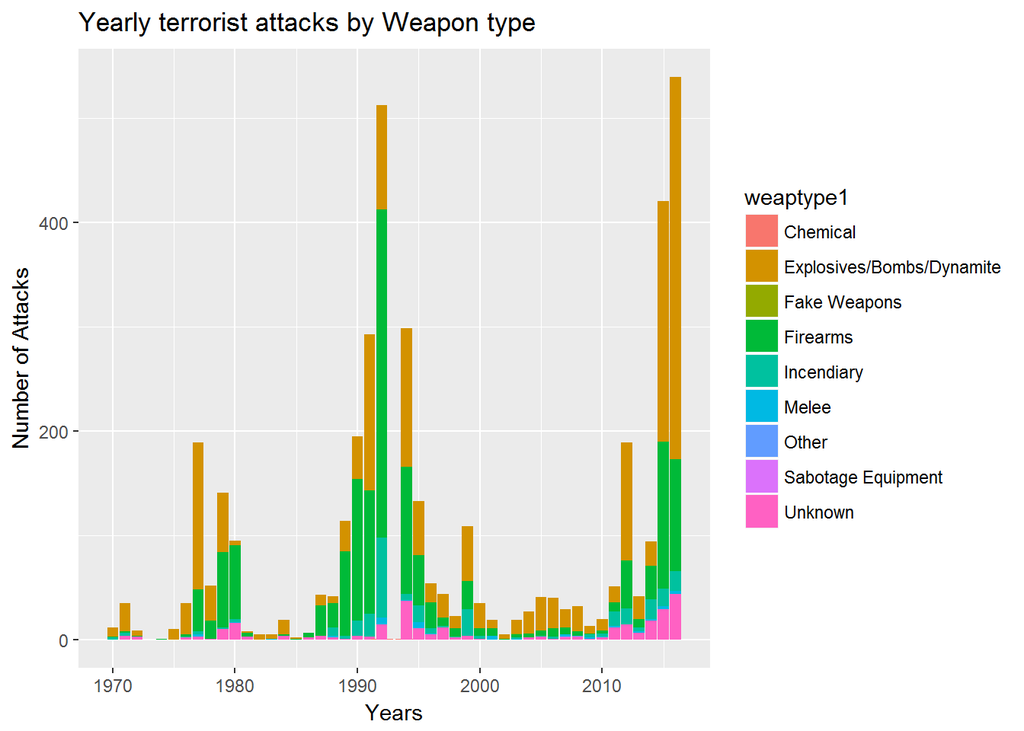

```r
  ggplot(data=gtd.turkey, aes(x=year,fill=weaptype1)) +
    geom_bar() + ggtitle("Yearly terrorist attacks by Weapon type")+
    labs(x = "Years", y = "Number of Attacks")
```

### Who are the targets for these groups?

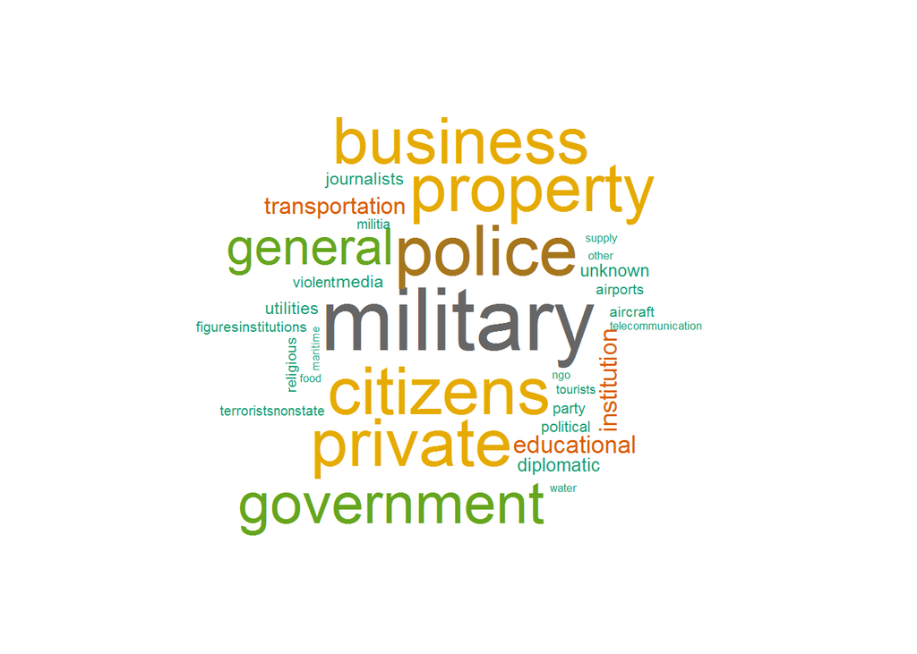

```r
library(igraph)
library(leaflet)
library(wordcloud)

library(igraph)
library(RColorBrewer)
library(tm)
library(NLP)
library(wordcloud)
wordcloud(gtd.turkey$targtype1,max.words = 100,random.order = FALSE,colors=brewer.pal(8, "Dark2"))
```

```r
library(shiny)
library(leaflet)
# Define UI

ui <- fluidPage(
  # Give the page a title
  titlePanel("Terrorism in Turkey"),
  # Generate a row with a sidebar
  sidebarPanel(
    sliderInput(inputId = "year", label = "Year of Casualty:",
                value = 2010, min = 1970, max = 2016),
    hr(),
    helpText("Source: Global Terrorism Database, START Consortium")
  ),
  # Show a plot of the generated distribution
  mainPanel(
    leafletOutput("map")
  )
)


# Define server logic

server <- shinyServer(function(input, output) {
  p = data.frame(year=gtd.turkey$year,lon=gtd.turkey$longitude, lat=gtd.turkey$latitude)

  output$map = renderLeaflet({
    leaflet() %>%
      addProviderTiles("Stamen.TonerLite") %>%
      setView(lng = 34.85427, lat = 39.91987, zoom = 5)
  })
  observe({
    leafletProxy("map") %>% clearShapes()%>%
      addCircles(data = p[grepl(input$year, p$year),],color = '#e67e22',weight = 10)
  })
})

# Run the application
shinyApp(ui, server)
```

Shiny applications not supported in static R Markdown documents

```r
#Leaflet Providers/  http://leaflet-extras.github.io/leaflet-providers/preview/
#Stamen.TonerLite
#Esri.WorldGrayCanvas
```

## References

Dataset source ==> [Global Terrorism Database](https://www.kaggle.com/START-UMD/gtd)

https://www.kaggle.com/dhrubajitdas/global-terrorism-full-analysis/data

http://start.umd.edu/gtd/downloads/Codebook.pdf

ggplot and visualization ==> http://r-statistics.co/ggplot2-Tutorial-With-R.html http://ggplot2.tidyverse.org/reference/ https://www.computerworld.com/article/2935394/business-intelligence/my-ggplot2-cheat-sheet-search-by-task.html

Shiny==> https://rstudio.github.io/leaflet/shiny.html http://shiny.rstudio.com/tutorial/

Other ==> http://zevross.com/blog/2014/08/04/beautiful-plotting-in-r-a-ggplot2-cheatsheet-3/

http://www.css.cornell.edu/faculty/dgr2/teach/R/R_corregr.pdf

https://www.programiz.com/r-programming

http://lightonphiri.org/blog/ggplot2-multiple-plots-in-one-graph-using-gridextra

http://www.cookbook-r.com/Graphs/Multiple_graphs_on_one_page_(ggplot2)/